# Practical Machine Learning (Final Project)

Nuno Melo

July 2, 2016

# 1 Executive Summary

In this project, our goal is to use data from accelerometers on the belt, forearm, arm, and dumbell of 6 participants and predict if the activity was done correctly or incorrectly in 20 different test cases. Participants were asked to perform barbell lifts correctly and incorrectly in 5 different ways. More information is available from the website here: http://groupware.les.inf.puc-rio.br/har.

# 2 Loading and preparing data for analysys

## 2.1 Loading data

We first load the raw data directly from the web sites. Training and testing datasets are included in the variable *trainingTesting*. This variable will be partioned later on. *Validation* dataset is loaded and put aside.

```r
# Reading data

trainingTesting <- fread("https://d396qusza40orc.cloudfront.net/predmachlearn/pml-training.csv",
                         na.strings=c(NA, "", "#DIV/0!"), stringsAsFactors = TRUE, verbose = FALSE)
validation <- fread("https://d396qusza40orc.cloudfront.net/predmachlearn/pml-testing.csv",
                 na.strings=c(NA, "", "#DIV/0!"), stringsAsFactors = TRUE)
```

## 2.2 Cleaning data

We now clean the data and prepare for manipulation. We have created a function, which removes all unecessary variables. They include:

1. The first 7 variables since they are not related to the actvities
2. All variables with more than 75% missing values (NAs)

```r
# Function cleaning and preparing data for analysis
createTechnicallyCorrectData <- function(df) {

    ## Removing first 7 columns, since they no influence predicting "classe"
    df <- df %>% dplyr::select(-(V1:num_window))

    ## Removing variables with more that 75% NAs
    NAColsAmount <- colSums(is.na(df))
    varAcceptableNA <- names(NAColsAmount[(NAColsAmount / nrow(df)) < 0.75])
    df <- df[, names(df) %in% varAcceptableNA]

    filter <- "kurtosis|skewness|max_yaw|min_yaw|amplitude_yaw"
    df <- df %>% dplyr::select(-matches(filter))

    df
}

## Calling function *createTechnicallyCorrectData* to clean and prepare data for prediction
dfTrainingTesting <- tbl_df(trainingTesting) %>% createTechnicallyCorrectData()
dfValidation <- tbl_df(validation) %>% createTechnicallyCorrectData()
```

We now have cleaned *trainingTesting* and *validation* data sets, both with **53** variables.

# 3 Data Partioning

Having clean and ready datasets we partion *trainingTesting* dataset in *dfTraining* and *dfTesting* datasets. Since this a random process, we set the seed to allow reproducibility.

```r
# Partioning data
set.seed(1234)
InTrain <- createDataPartition(y = dfTrainingTesting$classe, p=0.75,list=FALSE)

dfTraining <- dfTrainingTesting[InTrain,]
dfTesting <- dfTrainingTesting[-InTrain,]
dim(dfTraining);dim(dfTesting)
```

```
## [1] 14718    53
```

```
## [1] 4904   53
```

# 4 Building the models

In this project will we use three machine algorithms:

1. Decision Trees (*rpart*)
2. Random Forest decision trees with cross validation, to improve overfitting (*rf*)
3. Stochastic gradient boosting trees (*gbm*)

Secondly we will estimate accuracy, out of sample erros for the built models.

## 4.1 Model training creation

Before initiating the training procedure, we set a seed allowing reproducibility. At the end of each model training, we calculate the error in and out of sample errors.

### 4.1.1 Decision Trees

```r
set.seed(4321)
rpartModel <- train(classe ~ ., data=dfTraining, method="rpart")
```

### 4.1.2 Random Forest

#### 4.1.2.1 Cross validation used in Random Forest

Random forest is a very accurate prediction model. However to reduce overfitting, we have used **cross validation**. To this purpose we create a control function and tune some prameters. The model gets tested on 5 different parts of the data, repeated 3 times over. Then we chose the ‘oneSE’ function to select a model that is not the most complex.

```r
ctrl = trainControl(method="repeatedcv", number=5, repeats=3, selectionFunction = "oneSE")
set.seed(4321)
rfModel <- train(classe ~ ., data=dfTraining, method="rf", trControl= ctrl)
```

### 4.1.3 Stochastic gradient boosting trees

```r
set.seed(4321)
gbmModel <- train(classe ~ ., data=dfTraining, method="gbm")
```

# 5 In and Out of Sample Erros (Model accuracy)

We now perform models accuracy by first predicting *classe* values in the training and testing datasets, i.e. *dfTraining* and *dfTesting* respectively. Next we run *postResample* to calculate models accuracy and In and Out of Sample Errors.

1. Decision Trees (*rpart*)
2. Random Forest decision trees with cross validation, to improve overfitting (*rf*)
3. Stochastic gradient boosting trees (*gbm*)

## 5.1 Decision Trees

```r
rpartPredInSample <- predict(rpartModel, dfTraining)
rpartPredOutSample <- predict(rpartModel, dfTesting)

rpartErrorIn <- postResample(rpartPredInSample, dfTraining$classe)
rpartErrorOut <- postResample(rpartPredOutSample, dfTesting$classe)
```

- In sample, i.e in the training dataset, accuracy is: **0.4954478**
- Out of sample, i.e. in the testing dataset, accuracy is **0.49531**

## 5.2 Random Forest decision trees with cross validation

```r
rfPredInSample <- predict(rfModel, dfTraining)
rfPredOutSample <- predict(rfModel, dfTesting)

rftErrorIn <- postResample(rfPredInSample, dfTraining$classe)
rfErrorOut <- postResample(rfPredOutSample, dfTesting$classe)
```

- In sample, i.e in the training dataset, accuracy is: **1**
- Out of sample, i.e. in the testing dataset, accuracy is **0.9942904**

## 5.3 Stochastic gradient boosting trees

```r
gbmPredInSample <- predict(gbmModel, dfTraining)
gbmPredOutSample <- predict(gbmModel, dfTesting)

gbmtErrorIn <- postResample(gbmPredInSample, dfTraining$classe)
gbmErrorOut <- postResample(gbmPredOutSample, dfTesting$classe)
```

- In sample, i.e in the training dataset, accuracy is: **0.9747928**
- Out of sample, i.e. in the testing dataset, accuracy is **0.9653344**

# 6 Selected model

```r
rfModel
```

```
## Random Forest
##
## 14718 samples
##    52 predictor
##     5 classes: 'A', 'B', 'C', 'D', 'E'
##
## No pre-processing
## Resampling: Cross-Validated (5 fold, repeated 3 times)
## Summary of sample sizes: 11775, 11776, 11773, 11774, 11774, 11774, ...
## Resampling results across tuning parameters:
##
##   mtry  Accuracy   Kappa
##    2    0.9913484  0.9890546
##   27    0.9918467  0.9896855
##   52    0.9866828  0.9831530
##
## Accuracy was used to select the optimal model using  the one SE rule.
## The final value used for the model was mtry = 2.
```

```r
confusionMatrix(data=rfModel, reference=dfTesting$classe)
```

```
## Cross-Validated (5 fold, repeated 3 times) Confusion Matrix
##
## (entries are percentual average cell counts across resamples)
##
##           Reference
## Prediction    A    B    C    D    E
##          A 28.4  0.2  0.0  0.0  0.0
##          B  0.0 19.1  0.1  0.0  0.0
##          C  0.0  0.1 17.3  0.3  0.0
##          D  0.0  0.0  0.0 16.0  0.0
##          E  0.0  0.0  0.0  0.0 18.3
##
##  Accuracy (average) : 0.9913
```

```r
varImp(rfModel)
```

```
## rf variable importance
##
##   only 20 most important variables shown (out of 52)
##
##                   Overall
## roll_belt          100.00
## yaw_belt            79.26
## magnet_dumbbell_z   71.39
## magnet_dumbbell_y   62.80
## pitch_belt          62.00
## pitch_forearm       60.64
## magnet_dumbbell_x   52.46
## roll_forearm        51.00
## magnet_belt_z       45.28
## accel_dumbbell_y    44.19
## magnet_belt_y       43.59
## accel_belt_z        41.37
## roll_dumbbell       40.99
## accel_dumbbell_z    36.14
## roll_arm            33.54
## accel_forearm_x     32.91
## accel_arm_x         30.24
## yaw_dumbbell        29.82
## accel_dumbbell_x    29.15
## gyros_belt_z        28.19
```

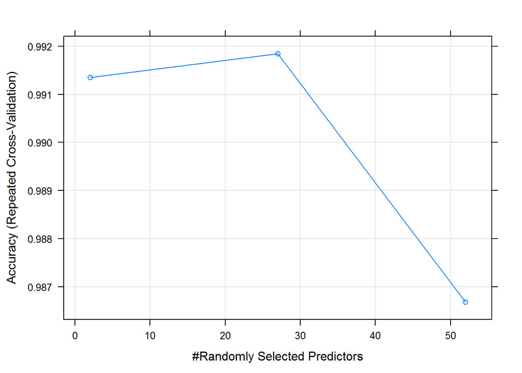

```r
plot(rfModel)
```

# 7 Conclusion and Model selection

Most important conclusions from the above

1. As expected, prediction accuracy is higher in the training than testing datasets
2. The accuracy from *gbm* and *rf* models is much higher than *rpart*
3. The model delivering better prediction accuracy is *rf* Random Forest with cross validation
4. In *rf* small improvment in accuracy is seen from using two predictors to 27 (the true best model)
5. The most important and in fact used, predictors used are *roll_belt* and *yaw_belt*

# 8 Predicting in the *validation* dataset

We now predict, with our best model, the results using the *dfValidation* dataset, and print it for peer evaluation.

```r
finalPrediction <- predict(rfModel, dfValidation)
```

```r
PredictionResults <- data.frame(
  problem_id=validation$problem_id,
  prediction=finalPrediction
)
print(PredictionResults)
```

```
##    problem_id prediction
## 1           1          B
## 2           2          A
## 3           3          B
## 4           4          A
## 5           5          A
## 6           6          E
## 7           7          D
## 8           8          B
## 9           9          A
## 10         10          A
## 11         11          B
## 12         12          C
## 13         13          B
## 14         14          A
## 15         15          E
## 16         16          E
## 17         17          A
## 18         18          B
## 19         19          B
## 20         20          B
```